# Creating a Powerpoint Document in R

# Files

Materials

Download Materials to practice on your own. Download, unzip, click on “Click_Here_to_Start.Rproj” and then inside of RStudio click on “ppt_parent_example.Rmd”

# Purpose of This Section

The purpose of this section is to explore how you can use a parent/child type relationship within R Markdown to produce a sequence of plots in a powerpoint file. This builds off of the previous example looking at the child/parent relationship. This example will show how you can create a powerpoint document with complex graphs that will iterate over several different columns. This example can be quite a bit more complicated, but that will be saved for a future example.

## Creating a Powerpoint from Markdown

Inside the parent document we must first load in the following libraries.

```r
library(knitr)
library(tidyverse)
library(survival)
library(survminer)
```

Here I am simply reading in a new dataset from the `survival` package. I am working through and simply modifying the variables to be more useful in a survival analysis/regression example.

```r
lung <- lung %>% mutate(
  age_group = case_when(
    age <= 55 ~ "LT 55",
    age > 55 & age <= 70 ~ "Between 55 & 70",
    age > 70 ~ "GT 70"))
vars <- c("time", "status", "sex", "age_group", "ph.ecog", "ph.karno", "pat.karno")
lung <- lung %>% select(all_of(vars))

var_names <- c("time", "status","Sex", "Age Group", "ECOG Performance", "Phys. Kanofsky", "Patient Karnofsky")
```

This example is just like the example we created in the child/parent tutorial. Here we are going to iterate over the 3rd through 7th columns and saving the code that is used in the child document.

```r
rmd <- sapply(
  3:7,
  function(x) {
    knit_expand("3_ppt_child.Rmd", x = x)
  }
)

rmd <- paste(rmd, collapse = "\n")
cat(rmd)
```

````
## \newpage
##
## # `r paste0("Survival Analysis stratified by ", var_names[3])`
##
## ```{r, echo = FALSE}
## # Creates a temporary variable to loop through
## temp_var <- unlist(lung[3])
##
## fit <- survfit(Surv(time, status) ~ temp_var, data = lung)
## names(fit$strata) <- str_replace(names(fit$strata), "temp_var", var_names[3])
## # Plots the survival analysis
## gg_norisk <- ggsurvplot(fit, risk.table = TRUE)
## # Sets up the png file to hold on to the graph temporarily
## norisk_png <- tempfile("norisk", fileext = ".png")
##
## # This builds a plot that can be saved as norisk_png
## norisk_png |>
##   ggsave(
##     plot = survminer:::.build_ggsurvplot(gg_norisk), width = 10, height = 10
##   )
##
## # Prints out the png file
## knitr::include_graphics(norisk_png)
## ```
##
## \newpage
## \newpage
##
## # `r paste0("Survival Analysis stratified by ", var_names[4])`
##
## ```{r, echo = FALSE}
## # Creates a temporary variable to loop through
## temp_var <- unlist(lung[4])
##
## fit <- survfit(Surv(time, status) ~ temp_var, data = lung)
## names(fit$strata) <- str_replace(names(fit$strata), "temp_var", var_names[4])
## # Plots the survival analysis
## gg_norisk <- ggsurvplot(fit, risk.table = TRUE)
## # Sets up the png file to hold on to the graph temporarily
## norisk_png <- tempfile("norisk", fileext = ".png")
````

[output cut: 75 more lines]

````
## gg_norisk <- ggsurvplot(fit, risk.table = TRUE)
## # Sets up the png file to hold on to the graph temporarily
## norisk_png <- tempfile("norisk", fileext = ".png")
##
## # This builds a plot that can be saved as norisk_png
## norisk_png |>
##   ggsave(
##     plot = survminer:::.build_ggsurvplot(gg_norisk), width = 10, height = 10
##   )
##
## # Prints out the png file
## knitr::include_graphics(norisk_png)
## ```
##
## \newpage
````

```r
rendered <- knit(text = rmd, quiet = TRUE)
cat(rendered, sep = "\n")
```

# Survival Analysis stratified by Sex

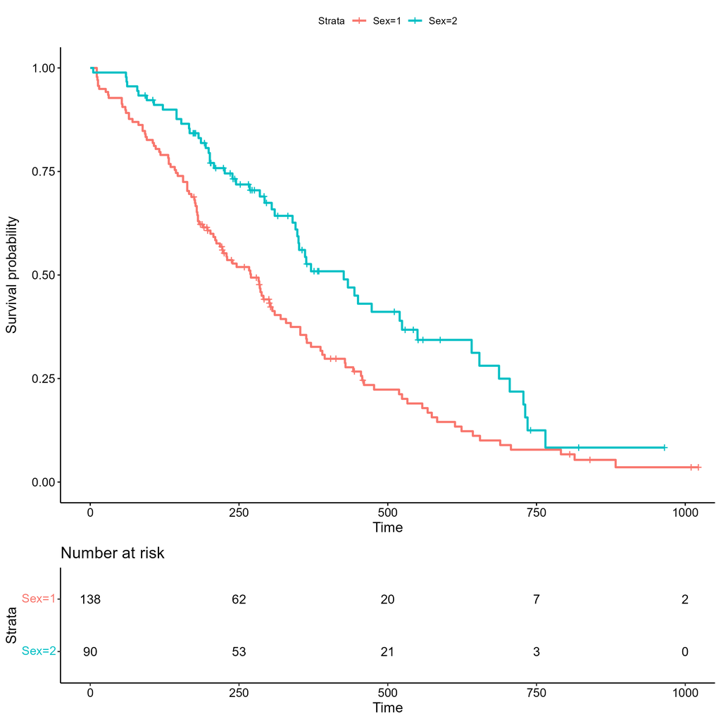

# Survival Analysis stratified by Age Group

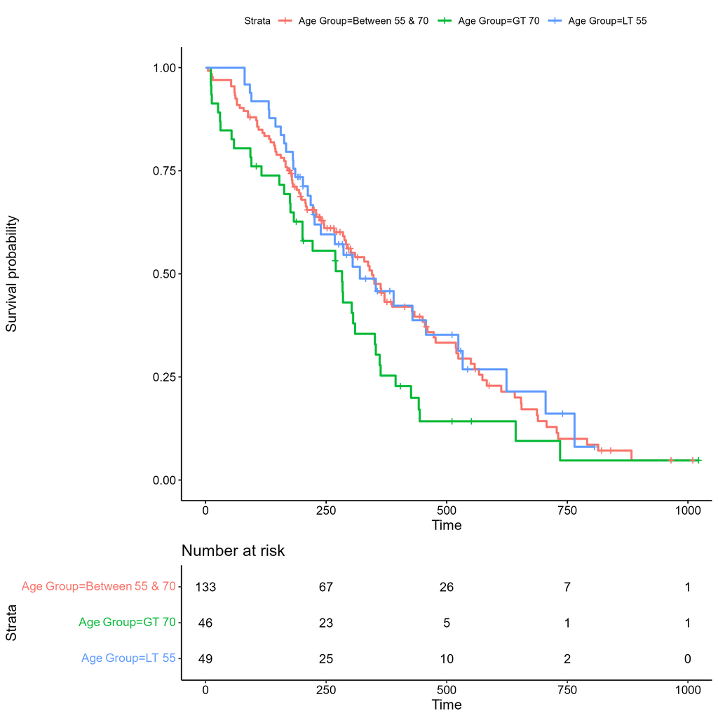

# Survival Analysis stratified by ECOG Performance

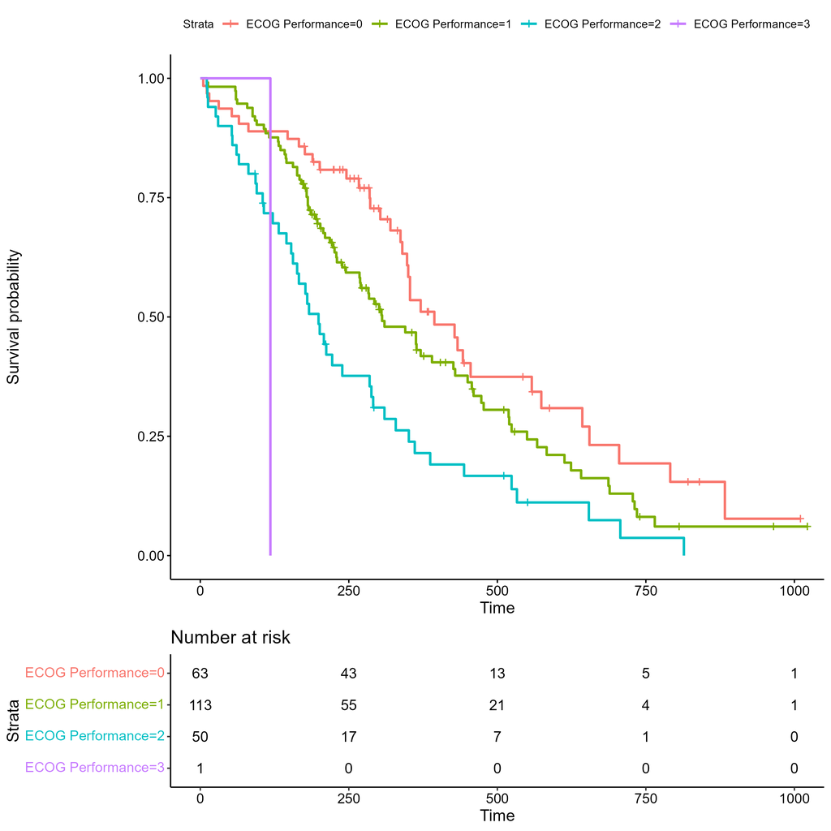

# Survival Analysis stratified by Phys. Kanofsky

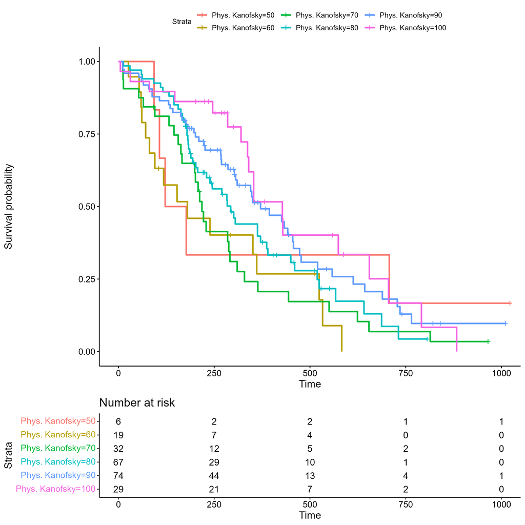

# Survival Analysis stratified by Patient Karnofsky

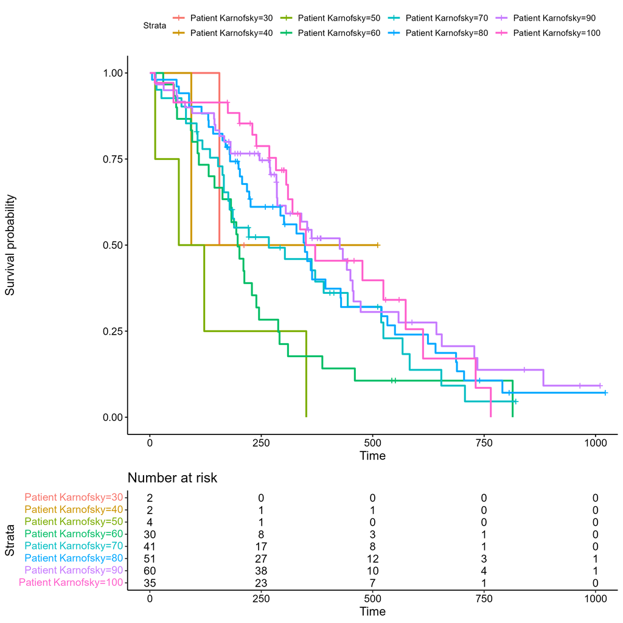

In this document I am knitting to an HTML to be able to show the code, etc. However, in your document you would knit to a ppt. You can do this by using the dropdown arrow next to the knit button and choosing ppt. Also, in the YAML (the header), you can include the following:

```r
# output:
#   powerpoint_presentation:
#     slide_level: 1
#     reference_doc: template1.potx
```

Using this format you can knit to a powerpoint and also provide a specific style so that the powerpoint is not simply a blank powerpoint.